# Human resource management in recession: Restructuring and alternatives to downsizing in times of crisis

Converted from PDF `Johnstone-RecessionDownsizingAlternatives-2024-HRMJ.pdf` · 20 pages · anchors: page `#pN`, block `#pN-bK`

Page 1

*Hum Resour Manag J.* 2024;34:138–157. wileyonlinelibrary.com/journal/hrmj **138**

Strathclyde Business School, University of Strathclyde, Glasgow, Scotland

#### **Correspondence**

Stewart Johnstone. Email: Stewart.johnstone@strath.ac.uk

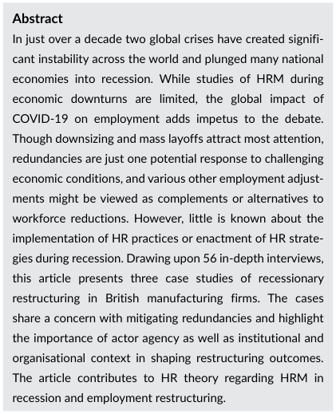

NOTE: figure/graphic rendered as an image from the PDF; its content is not machine-readable text. Caption (if any) follows as the next block.

**text found inside the figure**

**Abstract**

In just over a decade two global crises have created signifi-

cant instability across the world and plunged many national

economies into recession. While studies of HRM during

economic downturns are limited, the global impact of

COVID-19 on employment adds impetus to the debate.

Though downsizing and mass layoffs attract most attention,

redundancies are just one potential response to challenging

economic conditions, and various other employment adjust-

ments might be viewed as complements or alternatives to

workforce reductions. However, little is known about the

implementation of HR practices or enactment of HR strate-

gies during recession. Drawing upon 56 in-depth interviews,

this article presents three case studies of recessionary

restructuring in British manufacturing firms. The cases

share a concern with mitigating redundancies and highlight

the importance of actor agency as well as institutional and

organisational context in shaping restructuring outcomes.

The article contributes to HR theory regarding HRM in

recession and employment restructuring.

#### **R E S E A R C H A R T I C L E**

## **Human resource management in recession: Restructuring and alternatives to downsizing in times of crisis**

### **Stewart Johnstone**

DOI: 10.1111/1748-8583.12512

Received: 24 March 2021 Revised: 14 March 2023 Accepted: 26 April 2023

**Abbreviations:** CEO, Chief Executive Officer; COVID-19, Coronavirus disease; HR, human resources; HRM, human resource management; MNCs, multinational corporations; NVQ, national vocational qualification; OECD, organisation for economic co-operation and development; UK, United Kingdom; US, United States of America.

This is an open access article under the terms of the Creative Commons Attribution License, which permits use, distribution and reproduction in any medium, provided the original work is properly cited.

© 2023 The Authors. Human Resource Management Journal published by John Wiley & Sons Ltd.

Page 2

**139** JOHNSTONE

### **1 | INTRODUCTION**

In just over a decade two global crises have created significant economic, social and political instability across the

world, and plunged many national economies into recession, with important consequences for work, employment

and HRM (ILO, 2021). While the management of HR during recessions has tended to receive modest attention

in mainstream HRM scholarship (Johnstone et al., 2019; Teague & Roche, 2014), ongoing economic uncertainty

compounded by the global impact of COVID-19 on employment adds impetus to the debate (Dobbins et al., 2023).

In times of recession firms are often under pressure to cut costs including labour costs. Downsizing and mass

layoffs usually attract most attention (Edwards et al., 2020), and it is estimated that over 60 million jobs were lost

due to the 2008 global financial crisis (ILO, 2014), and that over 100 million jobs have been lost so far as part of the

ongoing international Covid-19 public health crisis (ILO, 2021). However, redundancies are just one measure which

can be introduced in times of economic distress, and firms may make various other HR changes, including freezing

recruitment, removing agency workers, redeploying staff, cutting pay, eliminating overtime and changing working

**K E Y W O R D S** downsizing, labour flexibility, layoffs, recession, restructuring, retrenchment

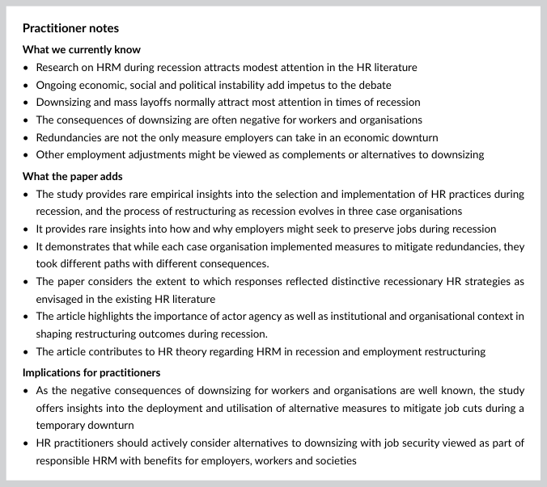

NOTE: figure/graphic rendered as an image from the PDF; its content is not machine-readable text. Caption (if any) follows as the next block.

**text found inside the figure**

**Practitioner notes**

**What we currently know**

• Research on HRM during recession attracts modest attention in the HR literature

• Ongoing economic, social and political instability add impetus to the debate

• Downsizing and mass layoffs normally attract most attention in times of recession

• The consequences of downsizing are often negative for workers and organisations

• Redundancies are not the only measure employers can take in an economic downturn

• Other employment adjustments might be viewed as complements or alternatives to downsizing

**What the paper adds**

• The study provides rare empirical insights into the selection and implementation of HR practices during

recession, and the process of restructuring as recession evolves in three case organisations

• It provides rare insights into how and why employers might seek to preserve jobs during recession

• It demonstrates that while each case organisation implemented measures to mitigate redundancies, they

took different paths with different consequences.

• The paper considers the extent to which responses reflected distinctive recessionary HR strategies as

envisaged in the existing HR literature

• The article highlights the importance of actor agency as well as institutional and organisational context in

shaping restructuring outcomes during recession.

• The article contributes to HR theory regarding HRM in recession and employment restructuring

**Implications for practitioners**

• As the negative consequences of downsizing for workers and organisations are well known, the study

offers insights into the deployment and utilisation of alternative measures to mitigate job cuts during a

temporary downturn

• HR practitioners should actively consider alternatives to downsizing with job security viewed as part of

responsible HRM with benefits for employers, workers and societies

Page 3

**140** JOHNSTONE

time (Cameron, 1991, 1994; Cascio, 2002; Pfeffer, 1998). Some of these adjustments may be viewed as comple-

mentary measures to be introduced in addition to workforce reductions to maximise short-term cost savings, or as

potential ways to mitigate redundancy, with compulsory dismissals viewed as a last resort. Thus while recessions can

present challenges to which firms must respond, employers have a range of HR adjustments from which they can

choose (Cascio, 2002; Pfeffer, 1998; van Wanrooy et al., 2013), and therefore some options regarding how exactly to

navigate an economic downturn (Bacon, 2008).

Yet while we know firms change their employment practices in times of recession (van Wanrooy et al., 2013),

few studies have explored *how* or *why* firms select and implement recessionary adjustments, or the extent to which

they devise distinctive HR strategies in times of depressed market conditions (Teague & Roche, 2014). To advance

the debate, this article draws upon 56 in-depth interviews to present case studies of three British manufacturing

firms deeply affected recession. Specifically, it considers how and why each organisation selected and implemented

HR adjustments as the recession evolved, as well as whether they devised and enacted distinctive HR recessionary

strategies.

Three main questions guided the empirical inquiry:

1) How did each organisation select and implement HR adjustments as the recession unfolded?

2) Why did they make the specific HR adjustments selected?

3) To what extent did each organisation devise and enact a distinctive HR strategy to navigate recession?

The article therefore makes several contributions. Empirically, by exploring how and why firms respond to recession

at the organisational level it offers rare empirical insight into the ‘black box’ of employment restructuring (Cook

et al., 2016; McLachlan et al., 2021), and responds to calls for more contextualised studies of HRM (Cooke, 2018;

Vincent et al., 2020). Conceptually, the paper contributes to ongoing debates in this journal regarding HRM in reces-

sion (Teague & Roche, 2014), downsizing (Cregan et al., 2021; Goyer et al., 2016; Harney et al., 2018; Muñoz-Bullón &

Sanchez-Bueno, 2014), and employment restructuring (Johnson and Mathews, 2022; McLachlan et al., 2020). Finally,

the study offers timely insights for HR policy and practice in times of great economic, social and political instability.

The remainder of the article is structured as follows. The next section presents some conceptual background

before outlining the research methods. The findings of three in-depth case studies of HR practices during recession

are then presented in turn. The findings are then discussed before drawing some conclusions.

### **2 | DOWNSIZING AND EMPLOYMENT RESTRUCTURING**

In recent decades employment downsizing, defined as permanent workforce reductions to improve organisational

efficiency (Budros, 1999), has gained strategic legitimacy across the world (McKinley et al., 2000). Large-scale

layoffs have become the norm in many nations, especially in times of economic distress (Cregan et al., 2020; Goyer

et al., 2016; Muñoz-Bullón & Sanchez-Bueno, 2014). In the US for example, mass layoff events peaked during the

recessions of 2001/2 and 2008/9 (Johnstone, 2019b), while in the early stages of the coronavirus pandemic over

20 million jobs were lost and unemployment surged to 15% (Look et al., 2021). Yet most empirical studies reveal

that downsizing has negative consequences for worker wellbeing and firm performance (Cascio et al., 2020; Cregan

et al., 2021; Freeman & Ehrhardt, 2012; Guthrie & Datta, 2008; Ritter-Hayashi et al., 2020), as well as a dispropor-

tionate effect on the vulnerable in society, including younger workers, the low paid and minorities (Bell et al., 2020).

A recent study of firms on the New York Stock Exchange during the period 1980–2016, also suggests that organisa-

tions that are quick to downsize tend to fare worse than competitors who delay job cuts (Cascio et al., 2020).

However, workforce reductions are not the only action employers can take during challenging economic condi-

tions. Other potential adjustments include freezing or cutting pay, reducing working time, redistributing work, reallo-

cating workers and revising job roles. Further measures include freezing recruitment and promotion, removing agency

Page 4

**141** JOHNSTONE

and contract staff, insourcing, loaning workers, or spending spare time on training and development. Manufacturing

firms might conduct maintenance activity or build for stock (Cascio, 2002; Pfeffer, 1998; van Wanrooy et al., 2013).

Some of these adjustments—such as those concerned with reducing payroll - may be viewed as *complementary* meas-

ures to be introduced in parallel with workforce reductions to maximise short-term cost savings. However, they could

also be viewed as part of a series of *alternative* measures which can be introduced over a period of the time, with

compulsory dismissals considered a last resort when all other options have been exhausted. Thus, while depressed

market conditions can present significant challenges to which firms must respond, managers remain critical actors in

the workplace, and can make strategic choices regarding exactly how to proceed (Bacon, 2008; Kochan et al., 1984).

Though the literature on HRM in recession remains modest, Teague and Roche (2014) identify three main

‘ideal type’ scenarios evident in the extant literature. First, is *‘pure restructuring’* where firms prioritise quick payroll

savings, primarily through workforce reductions. The approach resonates with what Cameron (1994, 197) described

as “throwing a grenade into a crowded room” with limited consideration of the consequences. This is thought to

be more common in liberal market economies such as the US, where an institutional context with more limited

employment protections, weakened trade unions and managerial incentive systems which reward short-term finan-

cial performance (Cascio, 2002; Dundon & Rafferty, 2018; Thompson, 2011), have been argued to encourage layoff

decisions in response to even modest economic challenges (Wood & Brewster, 2021). Nevertheless, liberal market

economies are not homogenous, and the ‘hire and fire’ and ‘employment at will’ approaches associated with the US

can be contrasted with the comparatively stringent redundancy legislation in the UK. Organisations in the same

institutional environment can also have quite different HR philosophies, with aggressive downsizers more likely to

consider staff to be disposable and easily replaceable (Cascio, 2002), or MNCs with origins in permissive liberal

market economies that prioritise short-term financial results rather than the longer term stakeholder view of coordi-

nated market economies (Boyle & McDonnell, 2013; Goergen et al., 2013).

The second scenario is *‘employment stabilisation’*, where firms commit to avoiding compulsory redundancies,

and instead seek alternative cost saving measures including pay cuts, working time reductions, voluntary layoffs and

the termination of contract and agency personnel. Usually associated with a no-compulsory layoff policy, firms will

instead ‘hoard’ labour. In exchange for high job security, staff are expected to be flexible in terms of pay, working

time, work tasks, and even job location. In a downturn, staff might be retrained or redeployed, and firms might also

reduce working time rather than cutting jobs. This is often supported by working time flexibility practices, such as

the use of Arbeitkonten (working time accounts) in Germany, which allow firms to make temporary staffing reduc-

tions while employees continue to receive a stable income. Job retention might also be encouraged by government

policy. Again, in Germany, state-sponsored Kurzarbeit (short work) schemes promote the retention of employees,

and compensate staff for lost income due to a reduction in working time (Bosch, 2009; Hijzen & Martin, 2013;

Pfeffer, 1998). However, the literature on employment stabilisation remains modest and empirical insights into its use

in the HRM literature are limited (Dyer et al., 1985; Teague & Roche, 2014).

Third, and lying somewhere in between these two poles is the notion of *‘responsible restructuring’*. Here employers

favour a wide range of adjustments to pay, working time and work organisation to mitigate the need for compulsory

dismissals. The emphasis is upon avoiding knee jerk redundancies, and downsizing is instead viewed as something to

mitigated—or considered a last resort—in response to challenging economic conditions (Cascio, 2002; Pfeffer, 1998;

Rogovsky et al., 2005). Discussions, especially in the European literature, also stress the importance of a fair process

of restructuring, as well as measures to ameliorate the negative impact of job loss and support displaced workers

back into the labour market (Ahlstrand, 2010; Bergström, 2007; Bosch, 2009; Forde et al., 2009; Hansen, 2009;

McLachlan, 2021; Papadakis, 2010; Rydell & Wigblad, 2011).

Concerns with job retention and responsible restructuring have attracted increasing international policy and

academic attention, especially after the 2008 global financial crisis (Ahlstrand, 2010; Bergström, 2007, ; EC, 2012;

Hansen, 2009; Johnson & Watt, 2022; McLachlan et al., 2021; Tsai & Shih, 2013; Tsai & Yen, 2020), and the global

impact of COVID-19 on employment has reignited the debate (Spencer et al., 2022; Stuart et al., 2021). However,

strategies approximating to employment stabilisation and responsible restructuring are thought to be more common

Page 5

**142** JOHNSTONE

in the coordinated market economies of Germanic European nations, where the institutional and regulatory envi-

ronment discourages a narrow short-term focus on dismissals, and traditions of social partnership encourage coop-

eration and social dialogue regarding less harmful restructuring approaches (Bergström, 2007; ILO, 2014; Wood

& Brewster, 2021). For example, only a minority of firms made mass layoffs in Germany during the 2008/9 global

financial crisis (Burda & Hunt, 2011), while in Sweden job security councils support re-employment, with almost 90%

redundant workers back in work within a year (Quintini & Venn, 2013). At an organisational level, such strategies

might also be expected in knowledge intensive or high skill settings, where workers are more likely to be viewed

as assets to be nurtured rather than costs to be cut (Cascio, 2002; Dyer et al., 1985; Teague & Roche, 2014), or in

MNCs with origins in coordinated market economies which promote long-term employment strategies (Boyle &

McDonnell, 2013).

Yet while we know that various restructuring practices and approaches are possible, and can depend upon and

be influenced by the institutional and organisational context (Wood & Brewster, 2021), much less is known about the

selection or implementation of HR practices or enactment of HR strategies at the organisational level during reces-

sion. Few studies have explored empirically how practices are selected or implemented at the organisational level, or

the extent to which they correspond with the ‘ideal type’ scenarios proposed in the literature.

A notable exception is a study of company level responses in Ireland during the 2008 global financial crisis

(Teague & Roche, 2014), which found limited evidence of strategies approximating to responsible restructuring or

employment stabilisation. This might be considered consistent with the view that such practices are less likely in a

liberal market economy like Ireland. Perhaps more curiously, however, the study also found little evidence of the pure

restructuring approach commonly associated with institutionally permissive liberal market economies. Instead, their

analysis found companies were evenly split between those that adopted narrow ‘pay-freeze focused’ changes, and

those that made a broader package of payroll focused ‘retrenchment’ measures, including short-time working and

redundancies. Yet contrary to expectations in the literature, these were not introduced like a “grenade in a crowded

room” with little concern for the consequences (Cameron, 1994, p. 197). Rather, payroll saving measures were intro-

duced in combination with communication and engagement measures.

Labour market evidence from the 2008 global financial crisis in the UK also suggests that firms implemented

a package of payroll saving measures including workforce reductions, freezing or cut wages, freezing recruitment,

reducing overtime, reducing working hours, and terminating agency and contract staff. However, it also reveals that,

despite being one of the few OECD nations which did not implement a state sponsored short time working scheme

to preserve jobs (Hijzen & Martin, 2013), there were fewer redundancies than previous recessions and the majority

were made voluntarily. Other employment adjustments were also common (van Wanrooy et al., 2013). This has raised

questions about the extent to which organisations might have been mitigating redundancies in favour of alternative

approaches as part of a commitment to job retention, or perhaps a reflection of greater labour flexibility allow-

ing workforce changes to be made without the need for mass redundances (Johnstone et al., 2019; van Wanrooy

et al., 2013).

However, answers to such questions are difficult to discern from aggregate labour market data or self-reported

employer practices, and instead lend themselves to more contextually-sensitive qualitative inquiry into the ‘black box’

processes of restructuring. However, besides a few exceptions (e.g. Cook et al., 2016; Johnstone, 2019a), studies into

how or why adjustment practices are selected or combined at an organisational level remain rare, and our knowledge

of HRM in recession remains limited as a result.

Drawing upon 56 in-depth interviews, this article presents three case studies of recessionary restructuring in

British manufacturing firms during the 2008/9 financial crisis, the most serious recession prior to the 2020 pandemic.

Specifically, it considers how and why each organisation selected and implemented recessionary adjustments as the

recession unfolded. It then considers whether organisational responses represented distinctive HR strategies, and the

extent to which they approximated to the ‘pure restructuring’, ‘employment stabilisation’ or ‘responsible restructuring

strategies’ envisaged in the extant literature on HRM in recession, as summarised in Table 1 (Teague & Roche, 2014).

Page 6

**143** JOHNSTONE

### **3 | METHODS AND RESEARCH CONTEXT**

Given the research aimed to understand how and why organisations responded to recession, as well as the process

and dynamics of restructuring at the organisational level, a qualitative case study approach was deemed most

appropriate. Case studies allow rich contextual data to be obtained and facilitate a more rounded consideration

of espoused policies and practices than can be achieved by relying upon one-off employer statements” (Sengupta

& Edwards, 2010, 241). Case studies also lend themselves to research seeking to look inside the ‘black box’ of a

process (Eisenhardt, 2021), and are “most appropriate for examining the processes by which events unfold as well as

for exploring…motives…and the interaction between the unit and its wider environment (Kitay et al., 1998, p. 104).

The research context was the British manufacturing sector following the 2008 recession, a time when around

half of manufacturers reported a ‘significant’ impact on business, while a quarter reported a ‘moderate’ impact (van

Wanrooy et al., 2013). A ‘firm in sector’ approach offers insights into developments in a similar context in terms of

products, markets, processes, technology and work organisation (Child & Smith, 1987; Smith et al., 1990). Manufac-

turing employs over 3 million people in the UK (Make UK, 2020) and many firms are used to peaks and troughs in

demand as trade expands and contracts, providing an ideal context to explore employment practices and HR strate-

gies in times of recession.

In identifying suitable cases, initial contact was made by email with HR Managers at manufacturing organisations

in the North of England through both personal contacts and cold calls. All respondents were invited to participate in a

short telephone interview to obtain some basic information regarding their organisations responses during the reces-

sion. Interest in participating in a more detailed case study was also gauged, though several participants declined.

The three firms that agreed form the basis of this study and are referred to by the pseudonyms ‘AutoParts’, ‘CraneCo’

and ‘FilterCo’ (see Table 2 for a summary of key characteristics). In each case the HR contact acted as gatekeeper

and facilitated site visits and access to participants. Semi structured interviews were arranged with senior/middle/

line managers, HR specialists and union/employee representatives. Follow up discussions were then conducted with

HR contacts on several occasions and provided the opportunity for clarification and amplification of key issues. In

total 56 interviews were conducted over a period of 18 months, ranging in length from 30 min to over two hours (see

Table 3 for a summary).

Each interview aimed to elicit a detailed account of how the respondent personally experienced the crisis, as well

as their recollection and perceptions of organisational responses as the recession unfolded. With permission, inter-

views were recorded and transcribed verbatim to facilitate detailed analysis. Questions aimed to obtain insight into

**TA B L E 1** Potential recessionary bundles.

| Purerestructuring | Employmentstabilisation | Responsiblerestructuring |
| --- | --- | --- |
| Headcountreduction | Nocompulsorylayoffs | Multiplepayrollcostreductions |
|  |  | spread over pay, employment |
|  |  | andworkingtimepractices |
| Additionalpayrollcostsavings | Workingtimereductions | Headcountreduction |
| Fewchangestoworkpractices | Paycuts | Changesinskillmixes |
| Littleconcernwithbehavioural | Voluntarylayoffs | Workingtimereorganisation |
| consequencesorunionengagement | Stafftrainedfornewpositions | Staffmobility |
|  | Insourcing |  |
|  | Cuts in agency, part time, contract |  |
|  | workers |  |
| Littleinclinationtoengagewithunions | Communicationandengagementactivity | Communicationandengagement |
|  |  | activity |

NOTE: table converted from PDF layout to HTML text; cell boundaries are reconstructed. See PDF if exact alignment matters.

*Note*: Adapted from Teague and Roche (2014, 180).

Page 7

**144** JOHNSTONE

the business context and market conditions, the impact of the recession, recessionary responses, and the outcomes

of those responses. Interviews were manually coded in several phases, using both broad categories identified in

the literature and included in the interview schedules (for example business conditions, recession, downsizing, HR

responses, impact), as well as codes which emerged from the data (for example, the role of corporation, working

time, regulation, morale), to interrogate transcripts and generate broader themes (Christians & Carey, 1989; Lofland

& Lofland, 1995). While there are some limitations in asking participants to recall a past event, this was mitigated

through corroboration with other accounts, as well as generous access to internal documentation including pres-

entation slides, HR polices and employee communications. This was valuable in confirming the chronology of events

and ensuring accuracy of respondent accounts in respect of factual issues. Though the findings are not statistically

generalisable (Stake, 1995), the research design is consistent with the aim of generating contextually-sensitive empir-

ical insights into HRM practices and processes during recession. Nevertheless, a degree of “analytical generalisation”

may be possible when compared with the findings of other studies of recessionary restructuring practices, and the

comparative ‘firm in sector’ design further enhances the opportunity for theory elaboration (Eisenhardt, 1989, 2021;

Smith et al., 1990; Yin, 2013).

**TA B L E 2** Three cases of recessionary restructuring.

#### **AutoParts CraneCo FilterCo**

Products New and replacement parts

for commercial vehicle markets

Cranes for marine and oil and

gas markets

New and replacement

filters for diverse range of industrial markets

[output not shown]

NOTE: table converted from PDF layout to HTML text; cell boundaries are reconstructed. See PDF if exact alignment matters.

**TA B L E 3** Summary of interviews.

#### **AutoParts CraneCo FilterCo**

Senior managers 4 3 5

| Linemanagers | 4 | 5 | 3 |
| --- | --- | --- | --- |
| HRspecialists 3 2 3 |  |  |  |
| Employees | 5 | 5 | 8 |
| Union/Employeerepresentatives 2 2 2 |  |  |  |
| Total | 18 | 17 | 21 |

NOTE: table converted from PDF layout to HTML text; cell boundaries are reconstructed. See PDF if exact alignment matters.

Page 8

**145** JOHNSTONE

### **4 | FINDINGS**

To maintain the sense of context and sequence of events, the three cases are presented in turn. Some background

context is provided, before considering how and why each organisation responded as it did. This is followed by a brief

assessment of each case. A detailed summary of the HR practices implemented during the crisis is provided in Table 4.

Table 5 also compares the main reasons given for the approaches taken across the three cases.

**TA B L E 4** HR practices during the 2008 crisis. [Colour table can be viewed at wileyonlinelibrary.com]

#### **AutoParts CraneCo FilterCo**

#### **“Protecting the core workforce” “A no lay off policy”**

#### **“Protecting jobs and the business”**

Pay adjustments

Pay cut for employees ✗ ✗ ✗

Pay cut for management ✓ ✗ ✓

Pay freeze ✓ ✓ ✓

| Headcountadjustments |  |  |  |
| --- | --- | --- | --- |
| Nocompulsorylayoffspolicy | ✗ ✓ |  | ✗ |
| Compulsorylayoffs | ✓ ✗ |  | ✓ |
| Voluntarylayoffs | ✓ ✗ |  | ✗ |
| Recruitmentfreeze | ✓ ✓ |  | ✓ |
| Reducecontractstaff | ✓ ✓ |  | ✓ |
| Reduceagencystaff | ✓ ✓ |  | ✓ |
| Workingtime Shorttimeworking ✗ ✓ ✓ Reduceovertime ✓ ✓ ✓ Reduceshifts ✓ ✓ ✓ Temporarylayoffs ✗ ✓ ✗ Workingtimeaccounts ✗ ✓ ✗ |  |  |  |
| Workorganisation |  |  |  |
| Staffredeployedinternally | ✓ ✓ |  | ✗ |
| Staffredeployedexternally | ✗ ✓ |  | ✗ |
| Insourcing | ✗ ✓ |  | ✓ |
| Buildingforstock | ✗ ✓ |  | ✗ |
| Trainingandtalentmanagement Stafftrainedinexistingroles ✗ ✓ ✓ Stafftrainedfornewroles ✓ ✗ ✗ Measurestoretaintalent ✗ ✓ ✗ Businessimprovementactivity ✗ ✗ ✓ |  |  |  |
| Communicationandengagement |  |  |  |
| Employeecommunications | ✓ ✓ |  | ✓ |
| Employeeengagement | ✓ ✓ |  | ✓ |
| Union/employeerepresentativeconsultation | ✓ ✓ |  | ✓ |

NOTE: table converted from PDF layout to HTML text; cell boundaries are reconstructed. See PDF if exact alignment matters.

*Note*: Red cross = no; Green tick = yes.

Page 9

**146** JOHNSTONE

### **4.1 | AutoParts—‘Protecting the core workforce’**

### 4.1.1 | Context

production operatives who work on a two-shift system Monday to Friday, plus a small nightshift. Prior to the reces-

sion the financial performance of the facility had reached record levels. Demand for new parts is dependent upon

volatile automotive markets, while demand for aftermarket replacement components is more stable, and provide

some cushioning from the vagaries of new vehicle markets. As the downturn emerged, vehicle manufacturers quickly

scaled back production plans and demand for new parts suddenly fell dramatically.

### 4.1.2 | HR responses

AutoParts had significant autonomy from its US parent organisation over workforce issues, and had developed a

production workforce comprising permanent employees on open-ended contracts, supported by agency workers

employed to help expand and contract staffing in line with automotive markets. The first response was therefore

to remove all agency workers, who comprised one third of operatives, many of whom had been with the business

for several years. A Manager explained that this was viewed as a necessary ‘insurance policy’ to manage market

conditions without the direct and indirect costs of redundancies, though acknowledged questions could be raised

regarding the prevalence of long-term agency staff. Nevertheless, all agency staff were invited to meetings to explain

the decision, and that they would be welcome back when conditions improved. Permanent operatives were then

redistributed across the different business streams.

The corporation also made recommendations to subsidiaries regarding freezing recruitment and overtime. This

also meant that Continuous Improvement Teams, which met for an hour at the end of each working week in paid

overtime, were also suspended. The corporation also encouraged short-time working though this was resisted by

local management. Instead, production moved to a single shift, resulting in savings in shift premia. Senior managers

**TA B L E 5** Rationale for minimising permanent layoffs. [Colour table can be viewed at wileyonlinelibrary.com]

**Rationale AutoParts CraneCo FilterCo**

Corporate philosophy ✗ ✓ ✗

| Localmanagementphilosophy | ✓ | ✓ | ✓ |
| --- | --- | --- | --- |
| Direct/Indirectcostsofredundancy ✓ ✓ ✓ |  |  |  |
| Viewingdownturnastemporary | ✓ | ✓ | ✓ |
| Retainingtalentforrecovery ✓ ✓+ ✓ |  |  |  |
| Strong pre-recession financial performance | ✓ | ✓ | ✓ |
| Pre-existing flexibility measures ✓ ✓ ✗ |  |  |  |
| StrongparentMNC | ✓ | ✓ | ✓ |
| Countryororigin ✗ ✓ ✗ |  |  |  |
| Corporategovernance | ✗ | ✓ | ✗ |
| Unionengagement ✗ ✗ ✗ |  |  |  |
| Employmentregulation | ✓ | ✗ | ✓ |

NOTE: table converted from PDF layout to HTML text; cell boundaries are reconstructed. See PDF if exact alignment matters.

HR function ✗ ✗ ✗

*Note*: Red cross = no; Green tick = yes.

Page 10

**147** JOHNSTONE

officially moved to short-time working, though as they continued to work full time it was viewed as a voluntary pay

cut. This was believed to be important to be seen to be following the corporate guidelines and demonstrating to staff

managers were not immune to the cutbacks and sharing the pain. As a senior manager explained:

“The short time working for senior managers wasn't a directive. It came from our CEO here as a

suggestion it might be a good idea. When it was put to us, of course I wanted to do it. Because why

not if otherwise some colleagues are going to be out of a job? It was the right thing to do, and we

continued to work 5 days a week or longer trying to make sure the business was protected”.

As poor market conditions endured and further savings were deemed necessary, attention returned to short-time

working and even the prospect of redundancies. Interestingly, management deemed a small, short redundancy

programme to be preferable to indefinite short time working for all staff, many of whom had already lost lucra-

tive shift pay and normally plentiful overtime opportunities. However, managers and workers recounted how the

emphasis was upon achieving a small number of voluntary redundancies. As a Manager explained, though compulsory

redundancies were not completely averted, the majority were voluntary:

"With the voluntary scheme it's about letting people who want to leave go. We had to think long and

hard about how we can rejuggle the business and rejuggle roles so that as much as possible the people

who left were those who wanted to. And thankfully in the majority of cases that was the case”.

### 4.1.3 | Assessment

AutoParts provides an example of an employer who experienced a sudden and dramatic decline in demand but

navigated the recession without recourse to large scale redundancies. This was possible as overall financial health

was reasonable given strong pre-recession trading conditions, a more stable aftermarket income stream, and the

resources of a global MNC. However, there was little evidence of redundancies being mitigated as part of an ethos of

responsible restructuring, or at least not in the way presented in the literature (Cascio, 2002; Teague & Roche, 2014).

Rather, large scale redundancies were averted primarily because of a high buffer of agency staff, many of whom had

worked for the organisation for several years. This dual labour market model, where permanent workers benefit

from enhanced job security at the expense of a disposable periphery of agency staff, was believed to offer the ability

to navigate peaks and troughs in demand without the costs of mass redundancies. However, managers and staff

acknowledged the moral and ethical questions of this segmented approach, especially as some agency personnel had

become long-serving members of staff.

The case therefore highlights how rather than being guided by a single HRM approach as envisaged in the exist-

ing literature on HRM in recession (Teague and Roche, 2014), a firm might view some workers as assets to be retained

and others as disposable commodities. This can even be among workers doing the same job and differentiated only

by employment status. An organisation can also blend ‘hard’ and ‘soft’ restructuring practices such as workforce

reductions with concerns for employee morale (Cook et al., 2016; Cregan et al., 2021), in ways not captured in exist-

ing categorisations of recessionary restructuring strategies (Cascio, 2002; Teague & Roche, 2014). In short, though

the case approximates most closely to ‘pure restructuring’ it is not exactly in the manner envisaged in the literature.

Page 11

**148** JOHNSTONE

### **4.2 | FilterCo—‘Protecting jobs and the business’**

### 4.2.1 | Context

FilterCo specialises in the design and manufacture of new and aftermarket filtration technologies for industrial

normally operates a single weekday shift supported by a small nightshift team. Prior to the recession, the business

had been performing well for several years, and strong market conditions meant overtime was usually plentiful.

However, as the recession began to emerge, orders quickly declined and though demand for replacement filters was

more resilient, overall production output quickly fell by 30%.

### 4.2.2 | HR responses

In contrast to AutoParts, most production employees were on full-time permanent contracts, with only a small

number of agency staff. When orders slowed, the first measure was to remove agency workers, many of whom were

long serving. As a Manager explained:

“I had to release four of them and I'm sitting across the table talking about them being agency staff

with us for capacity management reasons but they're on par with fulltime staff and have been with us

maybe 4 years. Yeah, it was pretty horrible”.

Further cost cutting measures then included freezing recruitment, terminating nightshifts, insourcing work, freezing

pay, banning overtime and limiting discretionary spend.

As the fall in orders continued, management considered further measures. However, as a senior manager

explained, local managers had some latitude to decide how to proceed, and agreed redundancies should be avoided

if possible:

“Not all areas of the business were down. We still had money coming in. Ultimately what you're trying

to do is protect the bottom line. But it's all too easy to shrink a business into the greatness but you're

generally cutting into the muscle as well as the fat. You have to be very careful. It's better to try and

make a business more flexible and efficient if you can, and then as you come out of recession you will

be better positioned to deal with it. A lot of companies trim back so far that when the economy recov-

ers they don't. But it's a blunt instrument. It's very difficult to recover from. There are lots of other

things you can do before you go for redundancies”.

While short-term working was mooted, it was decided instead that operatives in the new parts business stream with

the lowest demand would use spare time to participate in Business Improvement Projects. Affected workers under-

took their usual duties Monday to Wednesday, and spent the rest of the week participating in workshops on Lean,

Kaizen, Six Sigma and local problem-solving. These activities lasted 8 weeks and culminated with NVQ qualifications

and a celebratory event at a local hotel on completion. As a production manager explained:

“Rather than just saying there's no work for these people, we used them in a different way and got

them busy looking for efficiencies. It wasn't simply a case of orders have dropped and we need to start

chopping. They had time on their hands so we decided to use it to find ways of keeping people busy…

working on lean, looking at redesigning processes, reorganising the shopfloor”.

Page 12

**149** JOHNSTONE

However, as low demand continued, it was decided that further cuts were now necessary. This involved short-time

working for most staff and a voluntary pay cut for senior management. Again, any remaining spare time was to be

used for training. As an HR specialist explained:

“One thing we didn't do was cut the training budget. We decided consciously we aren't going to do

that because you can use the time to invest in people and allow them to upskill. Operators continued

to work on some NVQs and the office staff also used Monday as their training day”.

As a member of the customer service team recalled:

“It was good, and I think the company won itself some plaudits as you could see they were trying to

find ways of avoiding job losses. It wasn't a case of panicking and job cuts straight away, but protecting

people and their wages. Of course people were still very worried about what would be next. It was

also a bit weird as I remember we were short-time working but I still got sent off to do some training

course in Florida”.

However, redundancies were not completely avoided. As a Manager explained:

“It's always a last resort. We looked across the business streams and made small, targeted reductions

in line with the order profile reductions. It wasn't good but thankfully it wasn't a huge number either. I

think we lost 18 people so considering production was down 30% for so many months it was a handful

of staff really. And we avoided big redundancy bills”.

### 4.2.3 | Assessment

FilterCo experienced a sudden downturn in demand but had few pre-existing flexibility measures. Nevertheless, it

was viewed by respondents as a successful example of avoiding mass redundancies during recession. Union repre-

sentatives noted how from the outset management emphasised redundancies would only be a last resort, and that the

Managing Director held monthly ‘State of the Nation’ talks with the entire workforce. Local managers also stressed

the importance of maintaining morale through this stressful period. Business Improvement Projects were viewed as

an innovative and constructive use of staff time as they kept people busy, and resulted in recommendations which

were subsequently implemented.

Given the emphasis on protecting jobs and maintaining morale, with redundancies viewed as a last resort, there

are some elements of a ‘responsible restructuring’ approach (Cascio, 2002; Teague & Roche, 2014). Senior manage-

ment viewed redundancies as harmful, and there was a commitment at the outset that redundancies should not be

the first response in the event of an economic downturn if the business is still in good overall health. Fortunately, this

was the case given strong pre-recession trading, a resilient aftermarket division, and the support of a large diversified

global MNC. The Managing Director acknowledged that this strategy would not have been feasible had the organisa-

tion been on the brink of financial ruin. However, the business did not have the flexibility of a large temporary work-

force to align staffing levels with market demand. Yet as orders declined, management favoured training and business

improvement activities over short-time working, though this was implemented later as the recession endured, and

matched by a voluntary pay cut for senior managers. Nevertheless, redundancies were not completely avoided, and

it is curious that these were made on a compulsory rather than voluntary basis.

Page 13

**150** JOHNSTONE

### **4.3 | CraneCo—‘A no layoff policy’**

### 4.3.1 | Context

CraneCo manufactures heavy duty cranes for the global shipping and oil and gas industries, and the different demand

also a small local management and administration team. The site operates on a single weekday shift, supported by

a skeleton nightshift. As orders for cranes are typically placed years in advance, the impact of recessions is gradual.

Demand therefore fell slowly over 2 years from record levels to a point where there were periods forecast with no

production whatsoever.

### 4.3.2 | HR responses

Though the business operates in cyclical markets, the parent MNC has a long-standing commitment to secure perma-

nent employment. This was attributed to a combination of factors including private family ownership, the skilled

nature of the workforce, as well as the German origins and Mittelstand ethos of responsible business. As a senior

Manager explained, there was clear corporate protocol for managing during downturns:

“It's not about taking money out of the business here but a long term view of how to treat people. A

duty of care. And that means permanent employees in secure work. I'm responsible for the UK and I

cannot make someone redundant because of a lack of work. This requires approval from the Group

HR Director in Germany, and I don't think it would be looked upon favourably. There should not be a

better product on the market and to ensure this is the case, we need skilled motivated staff. We don't

want to lose valuable skills. Fluctuations of personnel on a large scale would be a distinct disadvantage

for us”.

Given this ‘no layoff’ commitment, management communicated to workers at an all staff meeting that they would not

be making compulsory redundancies, nor offered voluntary severance or early retirement schemes. The focus was

instead upon making alternative adjustments where necessary until market conditions improved.

In common with the other cases, the first response was to remove the small number of agency and contract

staff. Recruitment was also frozen, including apprentices who would not be hired on completion of their training, and

overtime was only to be authorised in exceptional circumstances. As work gradually declined and staff increasingly

had extra capacity, a range of measures were introduced to keep staff occupied. As one worker explained, employees

were used to being redeployed to other roles and tasks around the site in a downturn:

“When I started you were what you were and that's basically what you did. But that's all changed. You

need to be interchangeable and a bit flexible now. You can no longer say oh I'm a plater or an electri-

cian. You have to be able to say yes I'm a fitter but I can do other jobs. I guess it's like the business and

if you can only do one thing you're not very flexible are you?”.

Workers were also charged with general maintenance tasks. As a painter commented:

“I think I painted everything. The changing rooms. The mess room. The lines in the cark park. The roof.

They had me cleaning pretty much everything on site except maybe the gaffers car!”.

Page 14

**151** JOHNSTONE

Crane projects were also reallocated from sister European sites as part of an effort to share work, and for a period the

site took the more unusual step of producing earthmoving equipment for other divisions. Some workers were also

redeployed to other European sites, although workers acknowledged that this was primarily for training rather than

to help with production. A production manager also recalled that while cranes are normally build to order, the unusual

decision was made to build for stock to keep workers occupied and utilising their skills.

Having exhausted the above options, the last resort was a system of temporary layoffs where individual workers

were selected for a few weeks leave through a rota system. For most staff it involved using organisational working

time accounts, which allow workers to ‘bank’ a proportion of their normal pay which can then be drawn upon to

ensure continuity of pay if they are laid off temporarily due to a lack of work. As the scheme is not compulsory, staff

who were not already members could either join the scheme with 200 h credit to be paid back later, take any unused

paid holiday, or a period of unpaid leave.

### 4.3.3 | Assessment

The downturn in demand was more gradual at CraneCo. It is also the only case which completely avoided redundan-

cies and was able to weather the storm with its workforce intact. This was believed to reflect an established no-layoff

policy attributed to the German private ownership and heritage of the parent organisation, and an emphasis on

retaining skilled workers. As well as the usual initial cost saving measures, the firm had recourse to other adjustment

measures used routinely in times of low demand. These included training and temporary redeployment locally or

elsewhere in the corporation, as well the use of working time accounts, rolling temporary layoffs, and the sharing of

work with sister sites. However, it also took steps which were more unusual including building equipment for other

divisions and building for stock. In many respects in CraneCo the emphasis on labour hoarding resonates with the

notion of employment stabilisation, where firms espouse a no-layoff policy and use a range of alternative adjustments

to avoid job losses. In return for greater job security, CraneCo workers were expected to be flexible in relation to

their specific working arrangements, including what they do and where they work (Cascio, 2002; Dyer, et al., 1985;

Teague & Roche, 2014).

### **5 | DISCUSSION**

The aim of this paper was to enhance understanding of HRM in recessions, and it contributes by offering rare empir-

ical insights into how and why firms make employment changes during an economic downturn. Given the ‘firm in

sector’ approach (Smith et al., 1990), there are important similarities between the cases. All are medium sized UK

subsidiaries of international MNCs located in the North of England, and manufacture products for international

markets. Each organisation also self-identified as having been severely affected by recession. The cases therefore

offer an excellent window into how and why firms manage HRM and devise HR strategies in times of recession.

The first objective was to understand how organisations respond, and the extent to which they devise or enact

distinctive HR strategies in a downturn. In each case, firms deployed a similar range of initial payroll saving measures

in response to declining market conditions (see Table 4 for a summary of responses). These included removing agency

and contract staff, freezing pay and recruitment, banning overtime and reducing the number of shifts. Yet while

it has been argued that employers in liberal market economies often include permanent workforce reductions as

part of a package of payroll saving measures in times of economic distress (Cameron, 1994; Cascio, 2002; Edwards

et al., 2020; Wood & Brewster, 2021), managers in all three firms expressed a desire to mitigate compulsory redun-

dancies and acknowledged a vested interest in retaining staff if possible. Interestingly, this was true irrespective of

the parent company country of origin or workforce skills profile. This is consistent with studies which found existing

Page 15

**152** JOHNSTONE

theories and single variables can be hard to reconcile with actual restructuring practices, and calls for a more nuanced

understanding of employer behaviour (Goergen et al., 2013).

However, as well as offering insight into the HR practices deployed, the study also offers rare window into the

process and implementation of employment adjustments as the recession evolved (Cook et al., 2016). AutoParts and

CraneCo both operated in cyclical markets and had established tools for managing peaks and troughs in demand. At

AutoParts, where work was semi-skilled, a large buffer of temporary agency staff allowed staffing levels to expand

and contract in line with demand. When recession hit, the workforce could be quickly reduced without the need for

mass redundancies, and remaining staff were redeployed across the business or trained for new roles. Though a small

number of redundancies were not completely avoided, the majority were made on a voluntary basis, and managers

stressed the importance of communication and engagement activity throughout the restructuring process. Thus,

though the emphasis on workforce reduction and payroll cost reductions resonates with the pure restructuring, it is

not in the manner envisaged in the existing literature. Rather, the findings are consistent with evidence from Ireland

which found that even where the focus is upon ‘hard’ payroll cost savings and workforce reductions, firms might

combine ‘softer’ concerns with maintaining motivation and morale (Teague & Roche, 2014). It also highlights how the

existing scenarios assume a common HR approach, whereas managers might enact different approaches for different

groups of workers.

In contrast, at CraneCo workers were highly skilled and the organisation espoused a no-layoff policy. Use of

agency staff was limited and fluctuations in demand were instead addressed by redeploying staff within the site

or broader corporation, using spare time for training and maintenance activities, as well as working time measures.

When the recession hit, the firm was able to reorganise work and workers, before later implementing a range of

further measures including the use of working time accounts which allow working hours to be temporarily reduced

without a loss of pay for staff. The severity of the downturn also provoked the organisation to take unusual measures

such as building for stock. The ‘no layoffs’ approach demonstrates many of the hallmarks of employment stabilisation

strategies concerned with cutting costs while preserving jobs. Finally, at FilterCo, where work is semi-skilled and

demand more stable there was more limited experience of managing peaks and troughs in demand. Nevertheless,

managers took the view that compulsory redundancies should be a last resort, and utilised a range of other measures

as the recession unfolded as part of an effort to avoid permanent workforce reductions. The approach therefore

resonates with the notion of responsible restructuring (Cascio, 2002; Pfeffer, 1998).

The second main objective was to understand why organisations take the approach they do, and the study offers

empirical insights into the rationale for the approach taken in each case (see Table 5 for a summary). In all case manag-

ers were well versed in the direct and indirect costs of compulsory redundancies including severance payments,

loss of talent and organisational memory, and damage to employment relations and morale. The downturn was also

viewed as a temporary, meaning it was preferable to retain talent for when the economy inevitably rebounds, than

later rehiring and retraining new staff (Cascio, 2002). However, it was also acknowledged that preserving jobs is

easier when, as was the case, each organisation benefited from strong prerecession trading conditions, countercycli-

cal product markets, and the cushioning and financial strength of large diversified multinational parent organisations

(Gunnigle et al., 2019).

Other reasons for mitigating redundancies were more organisation specific. AutoParts and FilterCo, both subsid-

iaries of US MNCs, cited UK redundancy legislation as an incentive to avoid mass layoffs. Indeed, at AutoParts

employment protections were said to inform their belief that it was judicious to retain a sizeable buffer of agency

staff, precisely so they could expand and contract without the need for large scale redundancies. Thus, though UK

employment protections are more limited than some European nations, it highlights how they nevertheless appeared

to act as a disincentive to a ‘hire and fire’ approach. It is also worth noting how in the two US owned MNCs, managers

reported a degree of autonomy over HR issues including the precise package of recessionary implemented locally,

while at German-owned CraneCo the subsidiary was generally expected to follow established corporate protocol

which prioritised stable employment. It is also worth noting that though the importance of engagement between HR,

Page 16

**153** JOHNSTONE

unions and workforce representatives was a common theme, in all cases it was senior site managers who were said to

drive recessionary HR strategy, with unions consulted and HR advising and charged with implementation.

### **6 | CONCLUSION**

In times of recession, firms are usually under pressure to cut costs and often react by making changes to their

employment practices. Though existing evidence provides insight into the utilisation and diversity of adjustments at

the labour market level (Teague & Roche, 2014; van Wanrooy et al., 2013), we know much less about how and why

firms select or implement recessionary adjustments, or the extent to which they devise or enact distinctive reces-

sionary HR strategies during an economic downturn. By presenting rare empirical insights, this article offers a much

need window into the ‘black box’ of recessionary restructuring.

Firstly, it reveals that while firms in liberal market economies are believed to be more likely to downsize in times

of economic distress, often in combination with other payroll saving measures (Teague & Roche, 2014; Wood &

Brewster, 2021), there is nevertheless scope for localised agency in influencing the exact turn of events. As the cases

demonstrate, organisations facing similar economic conditions and structural constraints can follow quite differ-

ent paths, informed by a range of organisational factors, including management and corporate philosophies, the

perceived nature of the threat, organisational resources and financial health. The study therefore underlines the

scope for strategic choice in shaping restructuring outcomes (Kochan et al., 1984) and offers empirical insights into

how and why firms encountering similar economic challenges might respond in various ways, with different conse-

quences for workers and organisations.

Secondly, the study offers rare empirical insights into how and why employers might seek to retain jobs and

mitigate redundancies in times of recession. It is certainly noteworthy that despite facing the most severe economic

shock since the 1930s, all three firms espoused concerns with avoid redundancies and implemented a range of alter-

native adjustments to preserve jobs. While it is of course not possible to generalise about the level of labour hoarding

or job preservation from three case studies, the findings are nevertheless consistent with suggestions that redun-

dancy levels in the UK during the 2008 recession might have been lower than anticipated as some employers were

favouring alternative adjustments rather than job cuts (van Wanrooy et al., 2013). It thus demonstrates the complex

tensions between employment stability and flexibility in times of crisis (Murphy & Turner, 2023).

The study also demonstrates the potential utility of the ‘’recessionary scenarios' identified in the extant literature

on recessionary restructuring (Teague & Roche, 2014). CraneCo, which hoarded skilled labour, appears to represent

a rare case with the hallmarks of employment stabilisation, while FilterCo appears to approximate to an example of

responsible restructuring, at least at it is conceived in the voluntarist US ‘best practice’ HRM sense (Cascio, 2002;

McLachlan et al., 2021; Pfeffer, 1998), rather than the more institutional European social partnership interpretation

(Bergström, 2007). The findings therefore offer an interesting contrast to Teague and Roche (2014) who found scant

evidence of employment stabilisation or responsible restructuring during the financial crisis in Ireland. This might

be because Irish firms favoured more aggressive restructuring and downsizing (Gunnigle et al., 2019), or that their

incidence was too low to be identified (Teague & Roche, 2014).

Alternatively, it might also reflect a methodological limitation of quantitative analysis which can provide insights

into the overall pattern of responses but is less useful in explaining how and why organisations selected and

implement practices as a recession unfolds. This is important because, as Teague and Roche (2014) note, despite

widespread redundancies most firms also did not follow ‘pure restructuring’ - with its narrow focus on workforce

reductions and limited concern for the human consequences—believed to be common in liberal market economies.

Instead, firms usually enacted bundles of adjustments to pay, working time and work organisation, with firms most

affected adopting wider bundles. The importance of communication and engagement was also emphasised in all

cases of restructuring. Thus while it is perhaps possible to gauge instances of employment stabilisation or pure

restructuring from reported organisational practices, it is potentially more difficult to identify instances of responsible

Page 17

**154** JOHNSTONE

restructuring which requires insight into motives and sequencing of adjustments offered by qualitative inquiry. As

a result, it seems possible that some of bundles which Teague and Roche (2014) identified as ‘pay freeze focused’ or

‘general ‘retrenchment’ strategies might have resonated with ‘responsible restructuring’, which does not preclude job

loss but views workforce reductions as a last resort to be used when other options have been exhausted. Yet the find-

ings are consistent with Teague and Roche (2014) in demonstrating how employers blended ‘hard’ payroll reduction

with ‘soft’ HRM concerns such as communication and engagement. The findings also reveal how the extant reces-

sionary scenarios do not account for situations where employers adopt different approaches for different segments

of the workforce. To achieve a more nuanced understanding and advance theories of employment restructuring,

future research could explore restructuring practices and strategies during the COVID-19 pandemic, including the

behaviour of MNCs, as well as the extent to which firms might devise segmented strategies for different parts of

their workforce.

Finally, there are important lessons for policy and practice. First, HR practitioners must be aware of the deleteri-

ous consequences of downsizing for organisations and workers, as well as the potential benefits of alternative meas-

ures in times of recession. This study demonstrates the promise of creative and innovative alternatives to job cuts

and encourages practitioners to proactively consider job retention strategies in times of economic instability. While

these can be devised and implemented voluntarily by employers at the organisational level, especially when they have

both the desire and wherewithal to do so, greater state support and employment protections of the type found in

coordinated market economies which promote job retention and responsible restructuring would be welcome. The

2020 UK government Coronavirus Job Retention (furlough) scheme—though no panacea—is an interesting example

of one such novel development (Stuart et al., 2021).

#### **ACKNOWLEDGEMENTS**

I would like to thank Associate Editor Edel Conway and three anonymous reviewers for their support throughout the

review process. I would also like to thank Ian Cunningham, Dora Scholarios and Adrian Wilkinson for their feedback

on an early draft. The empirical work upon which this article is based was funded by a British Academy/Leverhulme

Trust Small Grant SG-121964.

#### **CONFLICT OF INTEREST STATEMENT**

The author declares no conflict of interest. The author made 100% contribution to the manuscript.

#### **DATA AVAILABILITY STATEMENT**

Research data are not shared.

#### **ORCID**

*Stewart Johnstone* https://orcid.org/0000-0002-7181-4795

#### **REFERENCES**

Ahlstrand, R. (2010). Social responsibility in connection with business closures: A study of the close-down of Eriks-

son telecom facilities in Norrkoping and Linköping. *Economic and Industrial Democracy*, *31*(4), 537–555. https://doi. org/10.1177/0143831x10365926 Bacon, N. (2008). Management strategy and industrial relations. In P. Blyton, E. Heery, N. Bacon, & J. Fiorito (Eds.), *The sage*

*handbook of industrial relations* (pp. 241–255). Sage. Bell, B., Codreanu, M., & Machine, S. (2020). What can previous recessions tell us about the Covid 19 downturn? Available

online at https://www.lse.ac.uk/News/Latest-news-from-LSE/2020/h-August-20/COVID-19-recession-is-having-adisproportionate-impact-on-the-most-vulnerable Bergström, O. (2007). Translating socially responsible workforce reduction—A longitudinal study of workforce reduction in a

Swedish company. *Scandinavian Journal of Management*, *23*(4), 384–405. https://doi.org/10.1016/j.scaman.2007.07.001 Bergström, O. (2019). Changing restructuring regimes in 11 European countries during and after the financial crisis. *European*

*Journal of Industrial Relations*, *25*(2), 95–111. https://doi.org/10.1177/0959680118770747

Page 18

**155** JOHNSTONE

Bosch, G. (2009). Working time and working time policy in Germany, paper prepared for the 2009 JILPT International Work-

shop Tokyo. Boyle, B., & McDonnell, A. (2013). Exploring the impact of institutional and organizational factors on the reaction of MNCs

to the global financial crisis. *Asia Pacific Business Review*, *19*(2), 247–265. https://doi.org/10.1080/13602381.2013.7 67639 Budros, A. (1999). A conceptual framework for analyzing why organizations downsize. *Organization Science*, *10*(1), 69–82.

https://doi.org/10.1287/orsc.10.1.69 Burda, M. C., & Hunt, J. (2011). *What explains the German labor market miracle in the great recession? (No. w17187)*. National

Bureau of Economic Research. Cameron, K. S. (1994). Strategies for successful organizational downsizing. *Human Resource Management*, *33*(2), 189–211.

https://doi.org/10.1002/hrm.3930330204 Cameron, K. S., Freeman, S. J., & Mishra, A. K. (1991). Best practices in white-collar downsizing: Managing contradictions. The

*Academy of Management Executive*, *5*(1), 57–73. https://doi.org/10.5465/ame.1991.4274469 Cascio, W. (2002). *Responsible restructuring: Creative and profitable alternatives to layoffs*. Berrett-Koehler Publishers. Cascio, W. F., Chatrath, A. and Christie-David, R. A. (2020). Antecedents and consequences of employment and asset restruc-

turing. *Academy of Management Journal*, *62*(4). Child, J., & Smith, C. (1987). The context and process of organizational transformation—Cadbury limited in its sector. *Journal*

*of Management Studies*, *24*(6), 565–593. https://doi.org/10.1111/j.1467-6486.1987.tb00464.x Christians, C., & Carey. (1989) The logic and aims of qualitative research, Research methods in mass communication, 354–374. Cook, H., MacKenzie, R., & Forde, C. (2016). HRM and performance: The vulnerability of soft HRM practices during recession

and retrenchment. *Human Resource Management Journal*, *26*(4), 557–571. https://doi.org/10.1111/1748-8583.12122 Cooke, F. L. (2018). Concepts, contexts, and mindsets: Putting human resource management research in perspectives. *Human*

*Resource Management Journal*, *28*(1), 1–13. https://doi.org/10.1111/1748-8583.12163 Cregan, C., Kulik, C. T., Johnston, S., & Bartram, T. (2021). The influence of calculative (“hard”) and collaborative (“soft”) HRM

on the layoff-performance relationship in high performance workplaces. *Human Resource Management Journal*, *31*(1), 202–224. https://doi.org/10.1111/1748-8583.12291 Dobbins, T., Johnstone, S., Kahancová, M., Lamare, R. J., & Wilkinson, A. (2023). Comparative impacts of the COVID-19

pandemic on work and employment—Why industrial relations institutions matter. *Industrial Relations: A Journal of Economy and Society*, *62*(2), 115–125. https://doi.org/10.1111/irel.12328 Dundon, T., & Rafferty, A. (2018). The (potential) demise of HRM? *Human Resource Management Journal*, *28*(3), 377–391.

https://doi.org/10.1111/1748-8583.12195 Dyer, L., Milkovicz, G., & Foltman, F. (1985). Contemporary employment stabilisation practices. In T. A. Kochan & T. Barocci

(Eds.), *Human resource management and industrial relations*. Little Brown. EC. (2012). Restructuring in Europe 2011, European commission, directorate-general for employment, social affairs and

inclusion. Edwards, E. Hewett, R. Farndale, E. McDonnell, M., & Wood, G. (2020), HRM in times of turmoil, *Human Resource Manage-*

*ment Journal*. Eisenhardt, K. M. (1989). Building theories from case study research. *Academy of Management Review*, *14*(4), 532–550.

https://doi.org/10.5465/amr.1989.4308385 Eisenhardt, K. M. (2021). What is the Eisenhardt Method, really? *Strategic Organization*, *19*(1), 147–160. https://doi.

org/10.1177/1476127020982866 Forde, C., Stuart, M., Gardiner, J., Greenwood, I., & Perret, R. (2009). *Socially responsible restructuring in an era of mass redun-*

*dancy, CERIC*. University of Leeds. Retrieved from http://lubswww.leeds.ac.uk/fileadmin/user_upload/Publications/ forde_et_al_WP5_01.pdf Freeman, S. J., & Ehrhardt, K. (2012). The antecedents of downsizing. In C. L., Cooper, A. Pandey & J. C. Quick (Eds.), *2012.*

*Downsizing: Is less still more?* Cambridge University Press. Goergen, M., Brewster, C., & Wood, G. (2013). The effects of the national setting on employment practice: The case of down-

sizing. *International Business Review*, *22*(6), 1051–1067. https://doi.org/10.1016/j.ibusrev.2013.02.001 Goyer, M., Clark, I., & Bhankaraully, S. (2016). Necessary and sufficient factors in employee downsizing? A qualitative compar-

ative analysis of lay-offs in France and the UK, 2008–2013. *Human Resource Management Journal*, *26*(3), 256–268. https://doi.org/10.1111/1748-8583.12101 Gunnigle, P., Lavelle, J., & Monaghan, S. (2019). Multinational companies and human resource management in Ireland during

recession: A retrospective from a highly globalized economy. *Thunderbird International Business Review*, *61*(3), 481–489. https://doi.org/10.1002/tie.21978 Guthrie, J. P., & Datta, D. K. (2008). Dumb and dumber: The impact of downsizing on firm performance as moderated by

industry conditions. *Organization Science*, *19*(1), 108–123. https://doi.org/10.1287/orsc.1070.0298 Hansen, G. B. (2009). *A guide to worker displacement: Some tools for reducing the impact on workers, communities and enterprises*.

Skills and Employability Department, ILO.

Page 19

**156** JOHNSTONE

Harney, B., Fu, N., & Freeney, Y. (2018). Balancing tensions: Buffering the impact of organisational restructur-

ing and downsizing on employee well-being. *Human Resource Management Journal*, *28*(2), 235–254. https://doi. org/10.1111/1748-8583.12175 Hijzen, A. and Martin, S. (2013). The role of short-time work schemes during the global financial crisis and early recovery: A

cross-country analysis. IZA journal of labor policy, *2*(1), pp. 1–31. ILO. (2014). *‘Global employment trends 2014’*. The Risk of a Jobless Recovery, ILO. ILO. (2021). COVID-19 and the world of work (7th ed.). https://www.ilo.org/wcmsp5/groups/public/@dgreports/@dcomm/

documents/briefingnote/wcms_767028.pdf Johnson, M., & Watt, L. (2022). Doing the right thing? An institutional perspective on responsible restructuring in UK local

government. *Human Resource Management Journal*, *32*(1), 76–91. https://doi.org/10.1111/1748-8583.12351 Johnstone, S. (2019a). Downsizing. In A. Wilkinson, N. Bacon, D. Lepak, & S. Snell (Eds.), *Sage handbook of human resource*

*management* (pp. 352–370). Sage. Johnstone, S. (2019b). Employment practices, labour flexibility and the Great Recession: An automotive case study. *Economic*

*and Industrial Democracy*, *40*(3), 537–559. https://doi.org/10.1177/0143831x17748370 Johnstone, S., Saridakis, G., & Wilkinson, A. (2019). The global financial crisis, work and employment: Ten years on. *Economic*

*and Industrial Democracy*, *40*(3), 455–468. https://doi.org/10.1177/0143831x19866532 Kitay, J., Callus, R., Whitfield, K., & Strauss, G. (1998). *The role and challenge of case study design in (pp. 101–112)*. Cornell

University Press. Kochan, T. A., McKersie, R. B., & Cappelli, P. (1984). Strategic choice and industrial relations theory. *Industrial Relations: A*

*Journal of Economy and Society*, *23*(1), 16–39. https://doi.org/10.1111/j.1468-232x.1984.tb00872.x Look, C., Pickert, R., & Pogkas, D. Europe’s giant job-saving Experiment pays off in pandemic. Available at https://www.

bloomberg.com/graphics/2021-furlough-jobs-unemployment-europe-united-states/ Lofland, J., & Lofland, L. H. (1995). *Analysing social settings: A guide to qualitative observation and analysis*. Wadsworth

Publishing. Make UK. (2020). Retrieved from https://www.makeuk.org/insights/publications/uk-manufacturing-the-facts-2019-20 McKinley, W., Zhao, J., & Rust, K. G. (2000). A sociocognitive interpretation of organizational downsizing. *Academy of Manage-*

*ment Review*, *25*(1), 227–243. https://doi.org/10.5465/amr.2000.2791612 McLachlan, C. J. (2021). Developing a framework for responsible downsizing through best fit: The importance of regulatory,

procedural, communication and employment responsibilities. *International Journal of Human Resource Management*, *33*, 1–29. https://doi.org/10.1080/09585192.2021.1958248 McLachlan, C. J., MacKenzie, R., & Greenwood, I. (2021). Victims, survivors and the emergence of ‘endurers’ as a reflection of

shifting goals in the management of redeployment. *Human Resource Management Journal*, *31*(2), 438–453. https://doi. org/10.1111/1748-8583.12314 Muñoz-Bullón, F., & Sanchez-Bueno, M. J. (2014). Institutional determinants of downsizing. *Human Resource Management*

*Journal*, *24*(1), 111–128. https://doi.org/10.1111/1748-8583.12017 Murphy, C., & Turner, T. (2023). Employment stability and decent work: Trends, characteristics and determinants in a liberal

market economy. *Journal of Industrial Relations*, 002218562311519. https://doi.org/10.1177/00221856231151966 Papadakis, K. (2010). *Restructuring enterprises through social dialogue: Socially responsible practices in times of crisis*. Interna-

tional Labour Organisation. Pfeffer, J. (1998). *The human equation: Building profits by putting people first*. Harvard Business Press. Quintini, G., & Venn, D. (2013). Back to work: Re-Employment, earnings and skill use after job displacement. Final report,

OECD, october. Ritter-Hayashi, D., Knoben, J., & Vermeulen, P. A. (2020). Success belongs to the flexible firm: How labor flexibility can

retain firm innovativeness in times of downsizing. *Long Range Planning*, *53*(3), 101914. https://doi.org/10.1016/j. lrp.2019.101914 Rogovsky, N., Ozoux, P., & Esser, D. (2005). *Restructuring for corporate success: A socially sensitive approach*. International

Labour Organisation. Rydell, A., & Wigblad, R. (2011). Company-level flexicurity during the restructuring process: A model. *Transfer: European*

*Review of Labour and Research*, *17*(4), 547–562. https://doi.org/10.1177/1024258911419781 Sengupta, S., & Edwards, P. (2010). Industrial relations and economic performance. In T. Colling & M. Terry (Eds.), *Industrial*

*relations: Theory and practice* (pp. 378–397). John Wiley. Smith, C., Child, J., & Rowlinson, M. (1990). *Reshaping work, the cadbury experience*. Cambridge University Press. Spencer, D. A., Stuart, M., Forde, C., & McLachlan, C. J. (2022). Furloughing and COVID-19: Assessing regulatory reform of

the state. *Cambridge Journal of Regions, Economy and Society*, *16*(1), 81–91. https://doi.org/10.1093/cjres/rsac026 Stake, R. (1995). *The art of case study research*. Sage. Stuart, M., Spencer, D. A., McLachlan, C. J., & Forde, C. (2021). COVID-19 and the uncertain future of HRM: Furlough, job reten-

tion and reform. *Human Resource Management Journal*, *31*(4), 904–917. https://doi.org/10.1111/1748-8583.12395

Page 20

**157** JOHNSTONE

Teague, P., & Roche, W. K. (2014). Recessionary bundles: HR practices in the Irish economic crisis. *Human Resource Manage-*

*ment Journal*, *24*(2), 176–192. https://doi.org/10.1111/1748-8583.12019 Thompson, P. (2011). The trouble with HRM. *Human Resource Management Journal*, *21*(4), 355–367. https://doi.

org/10.1111/j.1748-8583.2011.00180.x Tsai, C. F., & Yen, Y. F. (2020). Moderating effect of employee perception of responsible downsizing on job satisfaction and

innovation commitment. *International Journal of Human Resource Management*, *31*(15), 1913–1937. https://doi.org/10. 1080/09585192.2018.1424014 Tsai, P. C. F., & Shih, C. T. (2013). Labor union negotiations: Stepping stones or stumbling blocks for a responsible downsizing

strategy? Empirical tests in Taiwan. *International Journal of Human Resource Management*, *24*(3), 601–620. https://doi. org/10.1080/09585192.2012.694112 van Wanrooy, B., Bewley, H., Bryson, A., Forth, J., Freeth, S., Stokes, L., & Wood, S. (2013). *Employment relations in the shadow*

*of recession: Findings from the 2011 workplace employment relations study*. Palgrave Macmillan. Vincent, S., Bamber, G. J., Delbridge, R., Doellgast, V., Grady, J. and Grugulis, I. (2020). Situating human resource manage-

ment in the political economy: Multilevel theorising and opportunities for kaleidoscopic imagination. *Human Resource Management Journal*, *30*(4), 461–477. Wood, G., & Brewster, C. (2021). Human resource management in the Anglo-Saxon countries in parry E. In M. Morley &

C. Brewster (Eds.), *The oxford handbook of contextual approaches to human resource management* (pp. 159–176). OUP. Yin, R. (2013). *Case study research: Design and methods*. Sage.

**How to cite this article:** Johnstone, S. (2024). Human resource management in recession: Restructuring and

alternatives to downsizing in times of crisis. *Human Resource Management Journal*, *34*(1), 138–157. https://

doi.org/10.1111/1748-8583.12512